# Thailand_Export_2017_Summaries

For this project show about Thailand export in 2017.

## Import Libraries

```python
import urllib
import json
import numpy as np
import pandas as pd
import csv
import seaborn as sns #statistic data visualization
import matplotlib
import matplotlib.pyplot as plt
#!pip install squarify for treemap algorithms
import squarify
#!pip install chardet
```

# Collect API Data

## Import&Export Data

I got a data API from this site https://dataapi.moc.go.th/summary-countries

### Attributes

- (year)
- (month)
- (country_code)
- (country_name_en)
- (country_name_th)
- (value_usd_export)
- (acc_value_usd_export)
- (value_baht_export)
- (acc_value_baht_export)
- (value_usd_import)
- (acc_value_usd_import)
- (value_baht_import)
- (acc_value_baht_import)
- (value_usd_balance)
- (acc_value_usd_balance)
- (value_baht_balance)
- (acc_value_baht_balance)
- (value_usd_trade)
- (acc_value_usd_trade)
- (value_baht_trade)
- (acc_value_baht_trade)

```python
data1 = []
for i in range(1,13):
    url = "https://dataapi.moc.go.th/summary-countries?year=2017&month="+str(i)+"&limit=60"
    response = urllib.request.urlopen(url)
    raw_json = response.read().decode("utf-8")
    data = json.loads(raw_json)
    data1 += data
```

## Type of goods that Thailand export

### Attributes

- (year)
- (month)
- (country_code)
- (country_name_en)
- (country_name_th)
- (unit2th)
- (quantity)
- (acc_quantity)
- (value_usd)
- (acc_value_usd)
- (value_baht)
- (acc_value_baht)

API Data from https://data.moc.go.th/OpenData/ExportCommodityCountries

computer and car data be the subset of industry

```python
rice_export = []
for i in range(1,13):# loopเลขเดือนเพื่อให้ได้ค่าAPIทั้งปี
    url =  "https://dataapi.moc.go.th/export-commodity-countries?year=2017&month="+str(i)+"&com_code=101010000&limit=60"
    #url จะเลือกข้อมูลที่จะดึงมาโดยใช้ตัวแปร i แทนเดือนที่จะดึงและจะทำการดึงข้อมูลทั้งปีด้วย loop โดยใข้ i มีค่า1-12
    response = urllib.request.urlopen(url) #url request
    raw_json = response.read().decode("utf-8")
    data = json.loads(raw_json) #loadd json
    rice_export += data
fruits_export = []
for i in range(1,13):# loopเลขเดือนเพื่อให้ได้ค่าAPIทั้งปี
    url =  "https://dataapi.moc.go.th/export-commodity-countries?year=2017&month="+str(i)+"&com_code=101050000&limit=60"
    response = urllib.request.urlopen(url)
    raw_json = response.read().decode("utf-8")
    data = json.loads(raw_json)
    fruits_export += data
com_export = []
for i in range(1,13):# loopเลขเดือนเพื่อให้ได้ค่าAPIทั้งปี
    url =  "https://dataapi.moc.go.th/export-commodity-countries?year=2017&month="+str(i)+"&com_code=304010000&limit=60"
    response = urllib.request.urlopen(url)
    raw_json = response.read().decode("utf-8")
    data = json.loads(raw_json)
    com_export += data
car_export = []
for i in range(1,13):# loopเลขเดือนเพื่อให้ได้ค่าAPIทั้งปี
    url =  "https://dataapi.moc.go.th/export-commodity-countries?year=2017&month="+str(i)+"&com_code=321010400&limit=60"
    response = urllib.request.urlopen(url)
    raw_json = response.read().decode("utf-8")
    data = json.loads(raw_json)
    car_export += data
rubber_export = []
for i in range(1,13):# loopเลขเดือนเพื่อให้ได้ค่าAPIทั้งปี
    url =  "https://dataapi.moc.go.th/export-commodity-countries?year=2017&month="+str(i)+"&com_code=101090000&limit=60"
    response = urllib.request.urlopen(url)
    raw_json = response.read().decode("utf-8")
    data = json.loads(raw_json)
    rubber_export += data
industry_export = []
for i in range(1,13):# loopเลขเดือนเพื่อให้ได้ค่าAPIทั้งปี
    url =  "https://dataapi.moc.go.th/export-commodity-countries?year=2017&month="+str(i)+"&com_code=300000000&limit=60"
    response = urllib.request.urlopen(url)
    raw_json = response.read().decode("utf-8")
    data = json.loads(raw_json)
    industry_export += data
```

## Parse the collected data, and store it in an appropriate file format

```python
"""ทำการกำหนด Col ของข้อมูล และ กำหนดชื่อไฟล์"""
csv_columns = ['year','month',"country_code","country_name_en","country_name_th","value_usd_export","acc_value_usd_export","value_baht_export","acc_value_baht_export","value_usd_import","acc_value_usd_import","value_baht_import","acc_value_baht_import","value_usd_balance","acc_value_usd_balance","value_baht_balance","acc_value_baht_balance","value_usd_trade","acc_value_usd_trade","value_baht_trade","acc_value_baht_trade"]
csv_file = "data.csv"
with open(csv_file,'w',newline="",encoding="TIS-620") as csvfile:
    #encoding TIS คือ Decoding ที่เราใช้อ่านจาก file.csv แล้วนำค่ากลับมา Encodingเป็น UTF-8-sig เพื่อให้ตัว microsoft excel
    #ในเครื่องเราที่มีdefault ในการอ่านค่าเป็น utf-8 อ่านได้ ซึ่งจะทำให้อ่านค่าภาษาไทยได้ แต่ต้องลง pip install chardet ก่อน
    writer = csv.DictWriter(csvfile,fieldnames=csv_columns)
    writer.writeheader()
    for _data_ in data1: #find data in data1 list
        writer.writerow(_data_)
```

```python
"""จะทำการแปลงข้อมูลเสริม โดยเปลี่ยน csv_col ไม่เหมือนกับข้อมูลนำเข้าและส่งออก"""
csv_columns = ['year','month',"country_code","country_name_en","country_name_th","unit2th","quantity","acc_quantity","value_usd","acc_value_usd","value_baht","acc_value_baht"]
csv_file = "rice.csv"
with open(csv_file,'w',newline="",encoding="TIS-620") as csvfile:
    writer = csv.DictWriter(csvfile,fieldnames=csv_columns)
    writer.writeheader()
    for _rice_ in rice_export: #find data in data1 list
        writer.writerow(_rice_)
"""เราจะทำการใช้colเดิมแต่เปลี่ยนข้อมูลและชื่อ"""
csv_file = "fruits.csv"
with open(csv_file,'w',newline="",encoding="TIS-620") as csvfile:
    writer = csv.DictWriter(csvfile,fieldnames=csv_columns)
    writer.writeheader()
    for _fruits_ in fruits_export: #find data in data1 list
        writer.writerow(_fruits_)
csv_file = "com.csv"
with open(csv_file,'w',newline="",encoding="TIS-620") as csvfile:
    writer = csv.DictWriter(csvfile,fieldnames=csv_columns)
    writer.writeheader()
    for _com_ in com_export: #find data in data1 list
        writer.writerow(_com_)
csv_file = "car.csv"
with open(csv_file,'w',newline="",encoding="TIS-620") as csvfile:
    writer = csv.DictWriter(csvfile,fieldnames=csv_columns)
    writer.writeheader()
    for _car_ in car_export: #find data in data1 list
        writer.writerow(_car_)
csv_file = "rubber.csv"
with open(csv_file,'w',newline="",encoding="TIS-620") as csvfile:
    writer = csv.DictWriter(csvfile,fieldnames=csv_columns)
    writer.writeheader()
    for _rubber_ in rubber_export: #find data in data1 list
        writer.writerow(_rubber_)
csv_file = "industry.csv"
with open(csv_file,'w',newline="",encoding="TIS-620") as csvfile:
    writer = csv.DictWriter(csvfile,fieldnames=csv_columns)
    writer.writeheader()
    for _ind_ in industry_export: #find data in data1 list
        writer.writerow(_ind_)
```

# Load and represent the data using an appropriate data structure. Apply any pre-processing steps to clean/filter/combine the data

```python
"""เราจะทำการ readfilesโดยใช้ pandas โดยข้อมูลจะอยู่ใน folder data"""
#นอกจาก encoding TIS-620 ตอน convert to csv เราจะเลือกอ่านด้วยencode TIS ด้วย
datas = pd.read_csv("data/data.csv",encoding="TIS-620")
fruits = pd.read_csv("data/fruits.csv",encoding="TIS-620")
rice = pd.read_csv("data/rice.csv",encoding="TIS-620")
com = pd.read_csv("data/com.csv",encoding="TIS-620")
car = pd.read_csv("data/car.csv",encoding="TIS-620")
rubber = pd.read_csv("data/rubber.csv",encoding="TIS-620")
industry = pd.read_csv("data/industry.csv",encoding="TIS-620")
```

```python
#แสดงตัวอย่างข้อมูลตารางข้อมูลหลัก
datas.head(5)
```

|  | year | month | country_code | country_name_en | country_name_th | value_usd_export | acc_value_usd_export | value_baht_export | acc_value_baht_export | value_usd_import | ... | value_baht_import | acc_value_baht_import | value_usd_balance | acc_value_usd_balance | value_baht_balance | acc_value_baht_balance | value_usd_trade | acc_value_usd_trade | value_baht_trade | acc_value_baht_trade |
| --- | --- | --- | --- | --- | --- | --- | --- | --- | --- | --- | --- | --- | --- | --- | --- | --- | --- | --- | --- | --- | --- |
| 0 | 2017 | 1 | CN | CHINA | จีน | 2.152595e+09 | 2.152595e+09 | 7.673443e+10 | 7.673443e+10 | 3.661143e+09 | ... | 1.321131e+11 | 1.321131e+11 | -1.508547e+09 | -1.508547e+09 | -5.537864e+10 | -5.537864e+10 | 5.813738e+09 | 5.813738e+09 | 2.088475e+11 | 2.088475e+11 |
| 1 | 2017 | 1 | JP | JAPAN | ญี่ปุ่น | 1.598375e+09 | 1.598375e+09 | 5.697792e+10 | 5.697792e+10 | 2.189322e+09 | ... | 7.900214e+10 | 7.900214e+10 | -5.909471e+08 | -5.909471e+08 | -2.202421e+10 | -2.202421e+10 | 3.787698e+09 | 3.787698e+09 | 1.359801e+11 | 1.359801e+11 |
| 2 | 2017 | 1 | US | U.S.A. | สหรัฐอเมริกา | 1.931523e+09 | 1.931523e+09 | 6.885378e+10 | 6.885378e+10 | 1.010310e+09 | ... | 3.645725e+10 | 3.645725e+10 | 9.212128e+08 | 9.212128e+08 | 3.239653e+10 | 3.239653e+10 | 2.941833e+09 | 2.941833e+09 | 1.053110e+11 | 1.053110e+11 |
| 3 | 2017 | 1 | MY | MALAYSIA | มาเลเซีย | 7.458186e+08 | 7.458186e+08 | 2.658649e+10 | 2.658649e+10 | 8.873505e+08 | ... | 3.202022e+10 | 3.202022e+10 | -1.415319e+08 | -1.415319e+08 | -5.433727e+09 | -5.433727e+09 | 1.633169e+09 | 1.633169e+09 | 5.860671e+10 | 5.860671e+10 |
| 4 | 2017 | 1 | SG | SINGAPORE | สิงคโปร์ | 7.518106e+08 | 7.518106e+08 | 2.680009e+10 | 2.680009e+10 | 5.126024e+08 | ... | 1.849736e+10 | 1.849736e+10 | 2.392082e+08 | 2.392082e+08 | 8.302732e+09 | 8.302732e+09 | 1.264413e+09 | 1.264413e+09 | 4.529745e+10 | 4.529745e+10 |

5 rows × 21 columns

```python
#แสดงข้อมูลตัวอย่างข้อมูลรอง
"""ข้อมูลรองจะมีcolที่เหมือนกันดังนนั้นจะแสดงตัวอย่างแค่ตัวอย่างเดียว"""
fruits.head(5)
```

|  | year | month | country_code | country_name_en | country_name_th | unit2th | quantity | acc_quantity | value_usd | acc_value_usd | value_baht | acc_value_baht |
| --- | --- | --- | --- | --- | --- | --- | --- | --- | --- | --- | --- | --- |
| 0 | 2017 | 1 | VN | VIETNAM | เวียดนาม | เมตริกตัน | 83137.96 | 83137.96 | 68713095.0 | 68713095.0 | 2.449443e+09 | 2.449443e+09 |
| 1 | 2017 | 1 | CN | CHINA | จีน | เมตริกตัน | 66873.93 | 66873.93 | 62645888.0 | 62645888.0 | 2.233163e+09 | 2.233163e+09 |
| 2 | 2017 | 1 | HK | HONG KONG | ฮ่องกง | เมตริกตัน | 10255.25 | 10255.25 | 8084712.0 | 8084712.0 | 2.881990e+08 | 2.881990e+08 |
| 3 | 2017 | 1 | ID | INDONESIA | อินโดนีเซีย | เมตริกตัน | 7701.04 | 7701.04 | 6741632.0 | 6741632.0 | 2.403217e+08 | 2.403217e+08 |
| 4 | 2017 | 1 | US | U.S.A. | สหรัฐอเมริกา | เมตริกตัน | 1840.65 | 1840.65 | 3488176.0 | 3488176.0 | 1.243444e+08 | 1.243444e+08 |

```python
#datatype check
datas.dtypes
```

```
year                        int64
month                       int64
country_code               object
country_name_en            object
country_name_th            object
value_usd_export          float64
acc_value_usd_export      float64
value_baht_export         float64
acc_value_baht_export     float64
value_usd_import          float64
acc_value_usd_import      float64
value_baht_import         float64
acc_value_baht_import     float64
value_usd_balance         float64
acc_value_usd_balance     float64
value_baht_balance        float64
acc_value_baht_balance    float64
value_usd_trade           float64
acc_value_usd_trade       float64
value_baht_trade          float64
acc_value_baht_trade      float64
dtype: object
```

```python
#dtype check
rice.dtypes
```

```
year                 int64
month                int64
country_code        object
country_name_en     object
country_name_th     object
unit2th             object
quantity           float64
acc_quantity       float64
value_usd          float64
acc_value_usd      float64
value_baht         float64
acc_value_baht     float64
dtype: object
```

## Data explore&Null identify

```python
#เราสามารถใช้ loop ในการแสดงข้อมูลได้ทุกตารางโดยไม่concat แค่จะไม่ออกมาในรูป DF ที่ดี
data_list = ['datas','fruits','rice','com','car','industry']
for _datas_ in data_list:
    print(_datas_)
    print(eval(_datas_).head(3)) #Eval find string to object
```

```
datas
   year  month country_code country_name_en country_name_th  value_usd_export  \
0  2017      1           CN           CHINA             จีน      2.152595e+09
1  2017      1           JP           JAPAN         ญี่ปุ่น      1.598375e+09
2  2017      1           US          U.S.A.    สหรัฐอเมริกา      1.931523e+09

   acc_value_usd_export  value_baht_export  acc_value_baht_export  \
0          2.152595e+09       7.673443e+10           7.673443e+10
1          1.598375e+09       5.697792e+10           5.697792e+10
2          1.931523e+09       6.885378e+10           6.885378e+10

   value_usd_import  ...  value_baht_import  acc_value_baht_import  \
0      3.661143e+09  ...       1.321131e+11           1.321131e+11
1      2.189322e+09  ...       7.900214e+10           7.900214e+10
2      1.010310e+09  ...       3.645725e+10           3.645725e+10

   value_usd_balance  acc_value_usd_balance  value_baht_balance  \
0      -1.508547e+09          -1.508547e+09       -5.537864e+10
1      -5.909471e+08          -5.909471e+08       -2.202421e+10
2       9.212128e+08           9.212128e+08        3.239653e+10

   acc_value_baht_balance  value_usd_trade  acc_value_usd_trade  \
0           -5.537864e+10     5.813738e+09         5.813738e+09
1           -2.202421e+10     3.787698e+09         3.787698e+09
2            3.239653e+10     2.941833e+09         2.941833e+09

   value_baht_trade  acc_value_baht_trade
0      2.088475e+11          2.088475e+11
1      1.359801e+11          1.359801e+11
2      1.053110e+11          1.053110e+11

[3 rows x 21 columns]
fruits
   year  month country_code country_name_en country_name_th    unit2th  \
0  2017      1           VN         VIETNAM        เวียดนาม  เมตริกตัน
1  2017      1           CN           CHINA             จีน  เมตริกตัน
2  2017      1           HK       HONG KONG          ฮ่องกง  เมตริกตัน

   quantity  acc_quantity   value_usd  acc_value_usd    value_baht  \
0  83137.96      83137.96  68713095.0     68713095.0  2.449443e+09
```

[output cut: 52 more lines]

```
industry
   year  month country_code country_name_en country_name_th  unit2th  \
0  2017      1           US          U.S.A.    สหรัฐอเมริกา      NaN
1  2017      1           CN           CHINA             จีน      NaN
2  2017      1           JP           JAPAN         ญี่ปุ่น      NaN

   quantity  acc_quantity     value_usd  acc_value_usd    value_baht  \
0       0.0           0.0  1.676327e+09   1.676327e+09  5.975669e+10
1       0.0           0.0  1.488275e+09   1.488275e+09  5.305315e+10
2       0.0           0.0  1.228220e+09   1.228220e+09  4.378287e+10

   acc_value_baht
0    5.975669e+10
1    5.305315e+10
2    4.378287e+10
```

```python
datas.isnull().sum() #เราสามารถใช้คำสั่งนี้ในการตรวจสอบค่า Nullได้
```

```
year                      0
month                     0
country_code              0
country_name_en           0
country_name_th           0
value_usd_export          0
acc_value_usd_export      0
value_baht_export         0
acc_value_baht_export     0
value_usd_import          0
acc_value_usd_import      0
value_baht_import         0
acc_value_baht_import     0
value_usd_balance         0
acc_value_usd_balance     0
value_baht_balance        0
acc_value_baht_balance    0
value_usd_trade           0
acc_value_usd_trade       0
value_baht_trade          0
acc_value_baht_trade      0
dtype: int64
```

```python
#มีวิธีอื่นในการหาไหม?
"""เราสามารถที่จะหาค่า Null เป็น % ออกมาได้โดยใช้วิธีนี้"""
for miss in rice:
    "กำหนดค่ามาเก็บค่า null โดยออกมาเป็น % จากจำนวน miss หรือ ค่า null ที่ตรวจพบ"
    find_missing = np.mean(rice[miss].isnull())
    print('{} - {}%'.format(miss, round(find_missing*100))) #จัดการ formatเป็นการปัดเศษแล้วคูณ 100เพื่อให้เป็น%
```

```
year - 0.0%
month - 0.0%
country_code - 0.0%
country_name_en - 0.0%
country_name_th - 0.0%
unit2th - 0.0%
quantity - 0.0%
acc_quantity - 0.0%
value_usd - 0.0%
acc_value_usd - 0.0%
value_baht - 0.0%
acc_value_baht - 0.0%
```

```python
for miss in fruits:
    find_missing = np.mean(fruits[miss].isnull())
    print('{} - {}%'.format(miss, round(find_missing*100))) #จัดการ formatเป็นการปัดเศษแล้วคูณ 100เพื่อให้เป็น%
```

```
year - 0.0%
month - 0.0%
country_code - 0.0%
country_name_en - 0.0%
country_name_th - 0.0%
unit2th - 0.0%
quantity - 0.0%
acc_quantity - 0.0%
value_usd - 0.0%
acc_value_usd - 0.0%
value_baht - 0.0%
acc_value_baht - 0.0%
```

```python
for miss in car:
    find_missing = np.mean(car[miss].isnull())
    print('{} - {}%'.format(miss, round(find_missing*100))) #จัดการ formatเป็นการปัดเศษแล้วคูณ 100เพื่อให้เป็น%
```

```
year - 0.0%
month - 0.0%
country_code - 0.0%
country_name_en - 0.0%
country_name_th - 0.0%
unit2th - 0.0%
quantity - 0.0%
acc_quantity - 0.0%
value_usd - 0.0%
acc_value_usd - 0.0%
value_baht - 0.0%
acc_value_baht - 0.0%
```

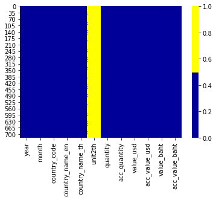

```python
#เราสามารถใช้ heatmapในการแสดงสีค่าข้อมูลที่มี null ได้
color = ['#000099','#ffff00'] #กำหนดสีให้ อันปกติสีน้ำเงิน อันที่ไม่ปกติจะเป็นค่า NaN
sns.heatmap(com.isnull(), cmap=sns.color_palette(color))
```

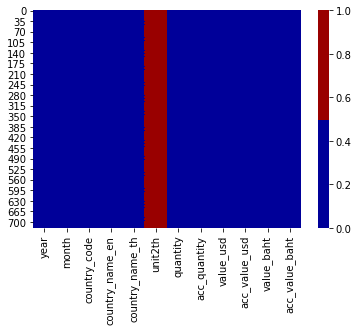

```python
#จาก heat map เราจะสังเกตตารางอื่นที่มีค่า Nan จะมีค่าNaN เป็น100%เหมือนกันหรือไม่
color = ['#000099','#990000']
sns.heatmap(com.isnull(), cmap=sns.color_palette(color))
```

```python
com.drop(columns = ['quantity','acc_quantity','unit2th'],inplace=True)
car.drop(columns = ['quantity','acc_quantity','unit2th'],inplace=True)
industry.drop(columns = ['quantity','acc_quantity','unit2th'],inplace=True)
```

```python
car.head()
```

|  | year | month | country_code | country_name_en | country_name_th | value_usd | acc_value_usd | value_baht | acc_value_baht |
| --- | --- | --- | --- | --- | --- | --- | --- | --- | --- |
| 0 | 2017 | 1 | CN | CHINA | จีน | 272060422.0 | 272060422.0 | 9.698247e+09 | 9.698247e+09 |
| 1 | 2017 | 1 | MY | MALAYSIA | มาเลเซีย | 58590401.0 | 58590401.0 | 2.088595e+09 | 2.088595e+09 |
| 2 | 2017 | 1 | JP | JAPAN | ญี่ปุ่น | 34470213.0 | 34470213.0 | 1.228773e+09 | 1.228773e+09 |
| 3 | 2017 | 1 | US | U.S.A. | สหรัฐอเมริกา | 27765133.0 | 27765133.0 | 9.897548e+08 | 9.897548e+08 |
| 4 | 2017 | 1 | KR | S. KOREA | เกาหลีใต้ | 21042334.0 | 21042334.0 | 7.501045e+08 | 7.501045e+08 |

```python
com.head()
```

|  | year | month | country_code | country_name_en | country_name_th | value_usd | acc_value_usd | value_baht | acc_value_baht |
| --- | --- | --- | --- | --- | --- | --- | --- | --- | --- |
| 0 | 2017 | 1 | US | U.S.A. | สหรัฐอเมริกา | 361827920.0 | 361827920.0 | 1.289822e+10 | 1.289822e+10 |
| 1 | 2017 | 1 | HK | HONG KONG | ฮ่องกง | 207846948.0 | 207846948.0 | 7.409203e+09 | 7.409203e+09 |
| 2 | 2017 | 1 | CN | CHINA | จีน | 121571603.0 | 121571603.0 | 4.333712e+09 | 4.333712e+09 |
| 3 | 2017 | 1 | NL | NETHERLANDS | เนเธอร์แลนด์ | 110636504.0 | 110636504.0 | 3.943904e+09 | 3.943904e+09 |
| 4 | 2017 | 1 | MY | MALAYSIA | มาเลเซีย | 86877926.0 | 86877926.0 | 3.096972e+09 | 3.096972e+09 |

```python
clean_data = datas.drop(columns = ['country_name_en','acc_value_usd_export','value_usd_export','value_usd_import','acc_value_usd_import',\
'acc_value_usd_balance','value_usd_trade','acc_value_usd_trade','value_usd_balance','value_baht_trade','acc_value_baht_trade'])
clean_data.head()
```

|  | year | month | country_code | country_name_th | value_baht_export | acc_value_baht_export | value_baht_import | acc_value_baht_import | value_baht_balance | acc_value_baht_balance |
| --- | --- | --- | --- | --- | --- | --- | --- | --- | --- | --- |
| 0 | 2017 | 1 | CN | จีน | 7.673443e+10 | 7.673443e+10 | 1.321131e+11 | 1.321131e+11 | -5.537864e+10 | -5.537864e+10 |
| 1 | 2017 | 1 | JP | ญี่ปุ่น | 5.697792e+10 | 5.697792e+10 | 7.900214e+10 | 7.900214e+10 | -2.202421e+10 | -2.202421e+10 |
| 2 | 2017 | 1 | US | สหรัฐอเมริกา | 6.885378e+10 | 6.885378e+10 | 3.645725e+10 | 3.645725e+10 | 3.239653e+10 | 3.239653e+10 |
| 3 | 2017 | 1 | MY | มาเลเซีย | 2.658649e+10 | 2.658649e+10 | 3.202022e+10 | 3.202022e+10 | -5.433727e+09 | -5.433727e+09 |
| 4 | 2017 | 1 | SG | สิงคโปร์ | 2.680009e+10 | 2.680009e+10 | 1.849736e+10 | 1.849736e+10 | 8.302732e+09 | 8.302732e+09 |

```python
"""ส่วนข้อมูลสินค้านำเข้าหรือข้อมูลรองเราจะลบชื่อให้เหลือแค่ภาษาไทยกับcode
    ในส่วนของค่าเงิน เราจะลบค่าเงิน usd ออก และ พวกน้ำหนักกับหน่วย """
rice.drop(columns = ['country_name_en', 'acc_value_usd','value_usd','quantity','acc_quantity','unit2th'],inplace=True)
fruits.drop(columns = ['country_name_en', 'acc_value_usd','value_usd','quantity','acc_quantity','unit2th'],inplace=True)
com.drop(columns = ['country_name_en', 'acc_value_usd','value_usd'],inplace=True)
car.drop(columns = ['country_name_en', 'acc_value_usd','value_usd'],inplace=True)
industry.drop(columns = ['country_name_en', 'acc_value_usd','value_usd'],inplace=True)
```

```python
clean_data.describe()
```

|  | year | month | value_baht_export | acc_value_baht_export | value_baht_import | acc_value_baht_import | value_baht_balance | acc_value_baht_balance |
| --- | --- | --- | --- | --- | --- | --- | --- | --- |
| count | 720.0 | 720.000000 | 7.200000e+02 | 7.200000e+02 | 7.200000e+02 | 7.200000e+02 | 7.200000e+02 | 7.200000e+02 |
| mean | 2017.0 | 6.500000 | 1.078397e+10 | 6.935176e+10 | 1.024289e+10 | 6.562749e+10 | 5.410752e+08 | 3.724265e+09 |
| std | 0.0 | 3.454452 | 1.710282e+10 | 1.289693e+11 | 2.084369e+10 | 1.550942e+11 | 1.107475e+10 | 7.568651e+10 |
| min | 2017.0 | 1.000000 | 8.403156e+06 | 5.023021e+07 | 7.890000e+02 | 4.105646e+06 | -5.647449e+10 | -5.170837e+11 |
| 25% | 2017.0 | 3.750000 | 1.227119e+09 | 6.472303e+09 | 8.898544e+08 | 4.490932e+09 | -1.284158e+09 | -4.997536e+09 |
| 50% | 2017.0 | 6.500000 | 3.754672e+09 | 1.967580e+10 | 2.298657e+09 | 1.336855e+10 | 6.281135e+08 | 2.667167e+09 |
| 75% | 2017.0 | 9.250000 | 1.283935e+10 | 7.204960e+10 | 1.131677e+10 | 6.154674e+10 | 3.098728e+09 | 1.726522e+10 |
| max | 2017.0 | 12.000000 | 9.538745e+10 | 9.979827e+11 | 1.369768e+11 | 1.515066e+12 | 4.501375e+10 | 3.902949e+11 |

จากตารางด้านบนเราจะเห็นได้ว่า จะมีบางค่าที่ติดลบเพราะ ขาดทุน รวมถึงบางประเทศที่แทบไม่มีรายได้จากการส่งออกเลย

```python
rice.describe()
```

|  | year | month | value_baht | acc_value_baht |
| --- | --- | --- | --- | --- |
| count | 720.0 | 720.000000 | 7.200000e+02 | 7.200000e+02 |
| mean | 2017.0 | 6.500000 | 2.373973e+08 | 1.451090e+09 |
| std | 0.0 | 3.454452 | 4.272901e+08 | 2.662922e+09 |
| min | 2017.0 | 1.000000 | 0.000000e+00 | 1.514700e+07 |
| 25% | 2017.0 | 3.750000 | 3.234238e+07 | 2.145936e+08 |
| 50% | 2017.0 | 6.500000 | 7.966060e+07 | 5.089401e+08 |
| 75% | 2017.0 | 9.250000 | 2.240849e+08 | 1.401892e+09 |
| max | 2017.0 | 12.000000 | 3.068237e+09 | 2.314962e+10 |

```python
rubber.describe()
```

|  | year | month | value_baht | acc_value_baht |
| --- | --- | --- | --- | --- |
| count | 706.0 | 706.000000 | 7.060000e+02 | 7.060000e+02 |
| mean | 2017.0 | 6.601983 | 2.897076e+08 | 1.990879e+09 |
| std | 0.0 | 3.410280 | 1.136343e+09 | 8.475201e+09 |
| min | 2017.0 | 1.000000 | 0.000000e+00 | 3.500000e+01 |
| 25% | 2017.0 | 4.000000 | 2.625747e+06 | 2.051125e+07 |
| 50% | 2017.0 | 7.000000 | 2.998345e+07 | 1.684541e+08 |
| 75% | 2017.0 | 10.000000 | 1.454689e+08 | 7.923986e+08 |
| max | 2017.0 | 12.000000 | 1.243465e+10 | 9.885835e+10 |

```python
industry.describe()
```

|  | year | month | value_baht | acc_value_baht |
| --- | --- | --- | --- | --- |
| count | 720.0 | 720.000000 | 7.200000e+02 | 7.200000e+02 |
| mean | 2017.0 | 6.500000 | 8.654530e+09 | 5.567641e+10 |
| std | 0.0 | 3.454452 | 1.354058e+10 | 1.017134e+11 |
| min | 2017.0 | 1.000000 | 2.523807e+08 | 3.413958e+08 |
| 25% | 2017.0 | 3.750000 | 9.491986e+08 | 5.325680e+09 |
| 50% | 2017.0 | 6.500000 | 3.146088e+09 | 1.625009e+10 |
| 75% | 2017.0 | 9.250000 | 9.669055e+09 | 5.746673e+10 |
| max | 2017.0 | 12.000000 | 7.037276e+10 | 7.627153e+11 |

```python
fruits.describe()
```

|  | year | month | value_baht | acc_value_baht |
| --- | --- | --- | --- | --- |
| count | 720.0 | 720.000000 | 7.200000e+02 | 7.200000e+02 |
| mean | 2017.0 | 6.500000 | 1.064949e+08 | 6.742581e+08 |
| std | 0.0 | 3.454452 | 4.766947e+08 | 3.238375e+09 |
| min | 2017.0 | 1.000000 | 0.000000e+00 | 2.867900e+04 |
| 25% | 2017.0 | 3.750000 | 9.446992e+05 | 4.182150e+06 |
| 50% | 2017.0 | 6.500000 | 4.650668e+06 | 2.133339e+07 |
| 75% | 2017.0 | 9.250000 | 2.002040e+07 | 1.102259e+08 |
| max | 2017.0 | 12.000000 | 4.924179e+09 | 3.486758e+10 |

```python
com.describe()
```

|  | year | month | value_baht | acc_value_baht |
| --- | --- | --- | --- | --- |
| count | 720.0 | 720.000000 | 7.200000e+02 | 7.200000e+02 |
| mean | 2017.0 | 6.500000 | 8.675388e+08 | 5.446360e+09 |
| std | 0.0 | 3.454452 | 2.397554e+09 | 1.737505e+10 |
| min | 2017.0 | 1.000000 | 0.000000e+00 | 7.656170e+05 |
| 25% | 2017.0 | 3.750000 | 1.059044e+07 | 4.671277e+07 |
| 50% | 2017.0 | 6.500000 | 6.397545e+07 | 3.664935e+08 |
| 75% | 2017.0 | 9.250000 | 4.574991e+08 | 2.688755e+09 |
| max | 2017.0 | 12.000000 | 1.759549e+10 | 1.805305e+11 |

```python
car.describe()
```

|  | year | month | value_baht | acc_value_baht |
| --- | --- | --- | --- | --- |
| count | 720.0 | 720.000000 | 7.200000e+02 | 7.200000e+02 |
| mean | 2017.0 | 6.500000 | 4.210111e+08 | 2.690597e+09 |
| std | 0.0 | 3.454452 | 6.768624e+08 | 5.032946e+09 |
| min | 2017.0 | 1.000000 | 0.000000e+00 | 1.028662e+07 |
| 25% | 2017.0 | 3.750000 | 2.822812e+07 | 1.688175e+08 |
| 50% | 2017.0 | 6.500000 | 1.141312e+08 | 5.980774e+08 |
| 75% | 2017.0 | 9.250000 | 5.068817e+08 | 2.296766e+09 |
| max | 2017.0 | 12.000000 | 3.492566e+09 | 3.575471e+10 |

## Explore some of data

```python
"""แสดงผลข้อมูล 5 ลำดับประเทศที่มีการส่งออกมากที่สุดในปี2017"""
month_12 = datas[datas["month"] == 12] #ดูข้อมูลเดือนสุดท้ายเพื่อตรวจสอบยอดสะสมของการส่งออก
month_12.loc[:,['country_name_th','acc_value_baht_export']].sort_values(by='acc_value_baht_export', ascending=False).head()
```

|  | country_name_th | acc_value_baht_export |
| --- | --- | --- |
| 660 | จีน | 9.979827e+11 |
| 662 | สหรัฐอเมริกา | 8.988233e+11 |
| 661 | ญี่ปุ่น | 7.465193e+11 |
| 667 | ฮ่องกง | 4.162574e+11 |
| 664 | เวียดนาม | 3.912109e+11 |

```python
#ข้อมูลประเทศที่เราทำการส่งออกน้อยที่สุด
month_12.loc[:,['country_name_th','acc_value_baht_export']].sort_values(by='acc_value_baht_export', ascending=False).tail()
#ใช้คำสั่ง. tail ในการ ดูจากท้ายตาราง
#ทำให้เกิดข้อสงสัยว่าบรูไนเป็น 1ในประเทศที่เราส่งออกน้อยที่สุดได้อย่างไร
```

|  | country_name_th | acc_value_baht_export |
| --- | --- | --- |
| 716 | อังโกลา | 6.290252e+09 |
| 711 | ไนจีเรีย | 5.738656e+09 |
| 718 | แอลจีเรีย | 3.674760e+09 |
| 719 | ยูเครน | 3.522981e+09 |
| 709 | บรูไน | 2.755455e+09 |

```python
#แสดงว่าประเทศจีนเป็นประเทศที่สร้างรายได้หรือกำไรให้เรามากที่สุดหรือไม่?
month_12.loc[:,['country_name_th','acc_value_baht_balance']].head()
#ใช้.loc[:,[]]ในการแสดงข้อมูลทั้งหมดในตารางตามคอลัมน์นี่ดำหนดโดยเลือกแสดงแค่ 5 บรรทัด
```

|  | country_name_th | acc_value_baht_balance |
| --- | --- | --- |
| 660 | จีน | -5.170837e+11 |
| 661 | ญี่ปุ่น | -3.513968e+11 |
| 662 | สหรัฐอเมริกา | 3.902949e+11 |
| 663 | มาเลเซีย | -4.717714e+10 |
| 664 | เวียดนาม | 2.215719e+11 |

```python
#จาก DFด้านบนแสดงให้เห็นว่า ประเทศที่กำหนดบางประเทศมีดุลการค้าติดลบเพราะการ import สินค้าจากประเทศทำให้เราใช้จ่ายไปทางประเทศนั้นเยอะกว่า
month_12.loc[:,['country_name_th','acc_value_baht_import']].head() #แสดงข้อมูลการนำเข้าสะสมทั้งปี
```

|  | country_name_th | acc_value_baht_import |
| --- | --- | --- |
| 660 | จีน | 1.515066e+12 |
| 661 | ญี่ปุ่น | 1.097916e+12 |
| 662 | สหรัฐอเมริกา | 5.085284e+11 |
| 663 | มาเลเซีย | 3.970258e+11 |
| 664 | เวียดนาม | 1.696389e+11 |

```python
#แสดงข้อมูลประเทศที่มีการส่งออกข้าวเยอะที่สุด 5 อันดับ
rice_12 = rice[rice["month"] == 12]
rice_12.loc[:,['country_name_th','acc_value_baht']].head()
#ปล.เบนินเป็นประเทศในทางฝั่งแอฟริกาตะวันตก
```

|  | country_name_th | acc_value_baht |
| --- | --- | --- |
| 660 | เบนิน | 2.314962e+10 |
| 661 | จีน | 1.942158e+10 |
| 662 | สหรัฐอเมริกา | 1.336726e+10 |
| 663 | แอฟริกาใต้ | 1.050270e+10 |
| 664 | แคเมอรูน | 9.174571e+09 |

```python
#แสดงข้อมูลประเทศที่มีการส่งออกสินค้าอุตสาหกรรมเยอะที่สุด 5 อันดับ
industry_12 = industry[industry["month"] == 12]
industry_12.loc[:,['country_name_th','acc_value_baht']].head()
```

|  | country_name_th | acc_value_baht |
| --- | --- | --- |
| 660 | สหรัฐอเมริกา | 7.627153e+11 |
| 661 | จีน | 7.207608e+11 |
| 662 | ญี่ปุ่น | 5.734552e+11 |
| 663 | ฮ่องกง | 3.878326e+11 |
| 664 | ออสเตรเลีย | 3.233964e+11 |

```python
#แสดงข้อมูลประเทศที่มีการส่งอุปกรณ์คอมพิวเตอร์เยอะที่สุด 5 อันดับ
com_12 = com[com["month"] == 12]
com_12.loc[:,['country_name_th','acc_value_baht']].head()
```

|  | country_name_th | acc_value_baht |
| --- | --- | --- |
| 660 | สหรัฐอเมริกา | 1.805305e+11 |
| 661 | ฮ่องกง | 1.037937e+11 |
| 662 | จีน | 7.159853e+10 |
| 663 | เนเธอร์แลนด์ | 4.834974e+10 |
| 664 | มาเลเซีย | 4.447746e+10 |

```python
#แสดงข้อมูลประเทศที่มีการส่งออกสินค้าจากยางเยอะที่สุด 5 อันดับ
rubber_12 = rubber[rubber["month"] == 12]
rubber_12.loc[:,['country_name_th','acc_value_baht']].head()
```

|  | country_name_th | acc_value_baht |
| --- | --- | --- |
| 646 | จีน | 9.885835e+10 |
| 647 | มาเลเซีย | 2.635788e+10 |
| 648 | ญี่ปุ่น | 1.525908e+10 |
| 649 | สหรัฐอเมริกา | 1.195348e+10 |
| 650 | เกาหลีใต้ | 7.361940e+09 |

```python
#แสดงข้อมูลประเทศที่มีการส่งอุปกรณ์รถยนต์เยอะที่สุด 5 อันดับ
car_12 = car[car["month"] == 12]
car_12.loc[:,['country_name_th','acc_value_baht']].head()
```

|  | country_name_th | acc_value_baht |
| --- | --- | --- |
| 660 | ญี่ปุ่น | 3.575471e+10 |
| 661 | อินโดนีเซีย | 3.077672e+10 |
| 662 | มาเลเซีย | 2.627629e+10 |
| 663 | จีน | 2.264144e+10 |
| 664 | สหรัฐอเมริกา | 2.069777e+10 |

```python
#แสดงข้อมูลประเทศที่มีการส่งผลไม้เยอะที่สุด 5 อันดับ
fruits_12 = fruits[fruits["month"] == 12]
fruits_12.loc[:,['country_name_th','acc_value_baht']].head()
```

|  | country_name_th | acc_value_baht |
| --- | --- | --- |
| 660 | เวียดนาม | 3.486758e+10 |
| 661 | จีน | 2.239691e+10 |
| 662 | ฮ่องกง | 6.129451e+09 |
| 663 | อินโดนีเซีย | 2.948631e+09 |
| 664 | สหรัฐอเมริกา | 2.154165e+09 |

# Data Analyze and Visualize

## bubble chart Compare sales amount in each country

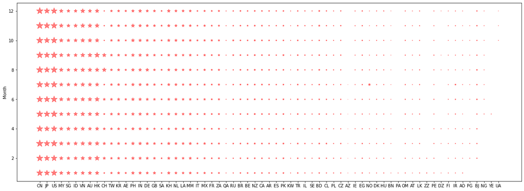

```python
plt.figure(figsize=(22,8))
# create data
y = clean_data['month']
x = clean_data['country_code']
z = clean_data['value_baht_export'] #เลือกsize

# use the scatter function
"""
    เราได้ทำการเลือก ขนาดของ scatter plot(bubble) โดยการหาร300000000 เพื่อให้แสดงข้อมูลในจำนวนที่น้อยบางส่วนให้ได้มากที่สุด
    แม้จะไม่ครอบคลุมทั้งหมดก็ตาม
    เราจะสังเกตได้ว่าขนาดของดาวคือปริมาณการส่งออกซึ่งเราสามารถสังเกตได้ว่าในแต่ละเดือนจะมีการส่งออกจัดอยู่ในกลุ่มไหน(มาก,กลาง,น้อย)
"""
plt.scatter(x, y, s=z/300000000,c = 'red',marker="*", alpha=0.5) #นำ z มาหารเพื่อให้ดาวไม่มีขนาดที่ใหญ่เกินไป
plt.ylabel('Month')
plt.show()
```

## Boxplot of export data

boxplot show group of data through quartiles.

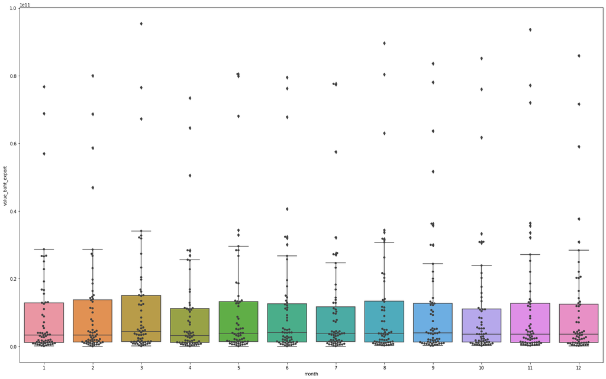

```python
plt.figure(figsize=(24,15))
ax = sns.boxplot(x="month", y="value_baht_export", data=clean_data)
ax = sns.swarmplot(x="month", y="value_baht_export", data=clean_data, color=".25")
```

As you can see from boxplot above this cell, mean of this data quite low and have a lot of outlier and extreme

## Export Comparison

Compare top 5 country that import goods from Thailand

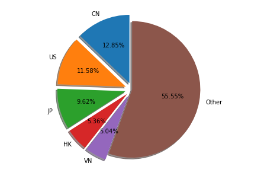

```python
sum_datas = clean_data[(clean_data['month']==12)]
sum_datas['acc_value_baht_export'].sum()
filter1 = sum_datas["country_code"]=="CN"
cn_pie = sum_datas[(filter1)]
us_pie = sum_datas[(sum_datas['country_code']=="US")]
jp_pie = sum_datas[(sum_datas['country_code']=="JP")]
hk_pie = sum_datas[(sum_datas['country_code'])=='HK']
vn_pie = sum_datas[(sum_datas['country_code'])=='VN']
fig = plt.figure()
ax = fig.add_axes([0,0,1,1])
ax.axis('equal')
explode = (0.1, 0.1, 0.1, 0.1,0.1,0) #สร้างความห่างของตัวpie chart ให้สังเกตได้ง่ายขึ้น
"""

"""
country = ['CN', 'US', 'JP', 'HK','VN','Other']
other = float(sum_datas['acc_value_baht_export'].sum()) - float(cn_pie['acc_value_baht_export']) - float(us_pie['acc_value_baht_export']) - float(jp_pie['acc_value_baht_export']) - float(hk_pie['acc_value_baht_export']) - float(vn_pie['acc_value_baht_export'])
val = [cn_pie['acc_value_baht_export'],us_pie['acc_value_baht_export'],jp_pie['acc_value_baht_export'],hk_pie['acc_value_baht_export'],vn_pie['acc_value_baht_export'],other]
ax.pie(val, labels = country ,autopct='%1.2f%%', explode=explode, shadow=True, startangle=90)# ทำมุม90 ในส่วนของอันแรก
plt.show()
```

From pie chart we can see that top 5 country nearly has half of all export amount.

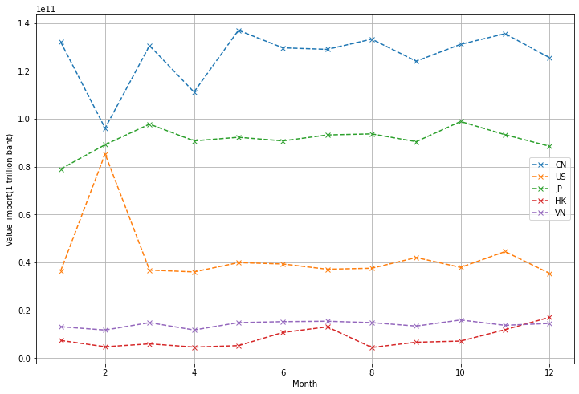

```python
plt.figure(figsize=(12,8))
x1 = [1,2,3,4,5,6,7,8,9,10,11,12]

graphs_cn = clean_data[(clean_data['country_code']=="CN")]
graphs_us = clean_data[(clean_data['country_code']=="US")]
graphs_jp = clean_data[(clean_data['country_code']=="JP")]
graphs_hk = clean_data[(clean_data['country_code']=="HK")]
graphs_vn = clean_data[(clean_data['country_code']=="VN")]
y1 = graphs_cn['value_baht_import']
y2 = graphs_us['value_baht_import']
y3 = graphs_jp['value_baht_import']
y4 = graphs_hk['value_baht_import']
y5 = graphs_vn['value_baht_import']

plt.plot(x1,y1 ,label = "CN",linestyle='--',marker='x')
plt.plot(x1,y2 ,label = "US",linestyle='--',marker='x')
plt.plot(x1,y3 ,label = "JP",linestyle='--',marker='x')
plt.plot(x1,y4 ,label = "HK",linestyle='--',marker='x')
plt.plot(x1,y5 ,label = "VN",linestyle='--',marker='x')
plt.grid()
plt.xlabel('Month')
plt.ylabel('Value_import(1 trillion baht)')
plt.legend()
# plt.show()
```

## Trade Balance

```python
month_12.loc[:,['country_name_th','acc_value_baht_balance']].head()
```

|  | country_name_th | acc_value_baht_balance |
| --- | --- | --- |
| 660 | จีน | -5.170837e+11 |
| 661 | ญี่ปุ่น | -3.513968e+11 |
| 662 | สหรัฐอเมริกา | 3.902949e+11 |
| 663 | มาเลเซีย | -4.717714e+10 |
| 664 | เวียดนาม | 2.215719e+11 |

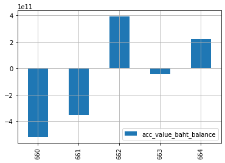

```python
"""เราจะplotกราฟสองแบบคือแบบมีค่าติดลบกับไม่มีค่าติดลบอิงจากภาพตารางด้านบน
"""
bar_g = (month_12.loc[:,['acc_value_baht_balance']].head())
bar_g.plot(kind="bar")
plt.grid()
```

- 660 is China
- 661 is Japan
- 662 is USA
- 663 is Malaysia
- 664 is Vietnam

## Comparison amount of export goods

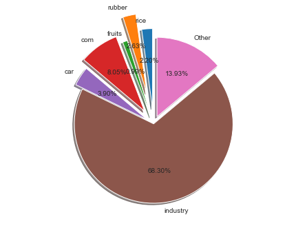

```python
rice_svalue = rice.loc[rice.month == 12].acc_value_baht.sum()
rubber_svalue = rubber.loc[rubber.month == 12].acc_value_baht.sum()
fruits_svalue = fruits.loc[fruits.month == 12].acc_value_baht.sum()
com_svalue = com.loc[com.month == 12].acc_value_baht.sum()
car_svalue = car.loc[car.month == 12].acc_value_baht.sum()
industry_svalue = industry.loc[industry.month == 12].acc_value_baht.sum()
industry_svalue = float(industry_svalue) - float(com_svalue) - float(car_svalue)#carและ คอมเป็นsubset ของ industry จึงต้องลบออก
fig = plt.figure()
ax = fig.add_axes([0,0,1,1])
ax.axis('equal')
explode = (0.2, 0.4, 0.1, 0.2,0.1,0,0.1)
country = ['rice', 'rubber', 'fruits', 'com','car','industry','Other']
others = float(sum_datas['acc_value_baht_export'].sum())-float(rice_svalue)-float(fruits_svalue)-float(rubber_svalue)-float(com_svalue)\
-float(car_svalue)-float(industry_svalue)
students = [rice_svalue,rubber_svalue,fruits_svalue,com_svalue,car_svalue,industry_svalue,others]
ax.pie(students, labels = country ,autopct='%1.2f%%', explode=explode, shadow=True, startangle=90)# ทำมุม90 ในส่วนของอันแรก
plt.show()
```

Industry Goods is the most thing that Thailand export to another country.

เราจะเห็นได้ว่าแม้จะหัก com และ car ออกจาก industry แต่สินค้าจากอุตสาหกรรมของประเทศไทยเป็นปริมาณที่ส่งออกเยอะมากซึงหลายคนอาจจะคิดว่าเราส่งออกข้าวได้เยอะที่สุดแต่จริงๆ ไม่ใช่ซึ่งหากที่จะนับจริงๆ ชนิดของสินค้าที่เราส่งออกเยอะที่สุดจะเป็นอุปกรณ์คอมพิวเตอร์ และอะไหล่รถยนต์ซึ่งได้มีแนวโน้มที่ยอดขายจะเพิ่มขึ้นเรื่อยๆในภายภาคหน้าด้วย

## Treemap show amount export sharing by country

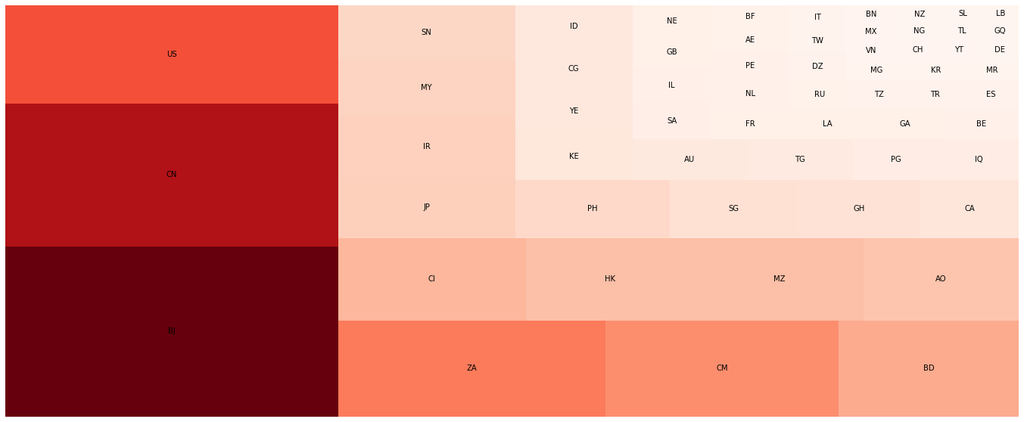

```python
plt.figure(figsize=(24,10))
"""
    Map color by values
    เราจะทำการหาค่า min maxของข้อมูล
    ทำการ normalize และจะมาเทียบกับสี
    ของ cmap
"""
cmap = matplotlib.cm.Reds #summer color
mini=min(rice.loc[rice.month == 12].acc_value_baht)
maxi=max(rice.loc[rice.month == 12].acc_value_baht)
norm = matplotlib.colors.Normalize(vmin=mini, vmax=maxi)
colors = [cmap(norm(value)) for value in rice.loc[rice.month == 12].acc_value_baht]
#ข้อมูลจะทำการไล่สีเข้มไปอ่อนหากกกำหนดสีเป็นสีเดียวกัน(cmap = Reds)
"""เราจะทำกการ import squarify มาใช้ในการทำ treemap"""
squarify.plot(sizes=rice.loc[rice.month == 12].acc_value_baht, label=rice.loc[rice.month == 12].country_code, alpha=1,color=colors )
plt.axis('off')
plt.show()
```

rice is one of the most thing that many Thai people think that rice is Thailand most export, but why benin is the country

that import rice from our country. Rice is main dish of Africa espescially Nigeria, because of tax Nigeria can't import our rice in large amount so Benin import

Thai rice and send it to Nigeria

treemap นี้จะแสดงชื่อประเทศที่นำเข้าข้าวจะประเทศไทยมากที่สุดในโลกซึ่งเบนินเป็นประเทศที่นำเข้าข้าวเยอะที่สุดจากเรา ทำไม???

ข้าวเป็นอาหารหลักของคนแอฟริกาโดยเฉพาะไนจีเรียแต่ไนจีเรียไม่สามารถนำเข้าข้าวจากเราได้มากเนื่องจากภาษีจึงได้ใช้การค้าขายผ่านพรมแดนเบนินแทน

รายละเอียดเพิ่มเติม:https://www.ryt9.com/s/exim/2760236

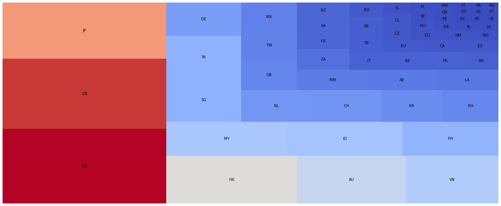

```python
plt.figure(figsize=(24,10))
cmap = matplotlib.cm.coolwarm#ไล่สีจากโทนร้านไปเย็น ค่ากลางคือข้อมูลโทนร้อนน้อยและเย็นน้อย
mini=min(industry.loc[industry.month == 12].acc_value_baht)
maxi=max(industry.loc[industry.month == 12].acc_value_baht)
norm = matplotlib.colors.Normalize(vmin=mini, vmax=maxi)
colors = [cmap(norm(value)) for value in industry.loc[industry.month == 12].acc_value_baht]

squarify.plot(sizes=industry.loc[industry.month == 12].acc_value_baht, label=industry.loc[industry.month == 12].country_code, alpha=1,color=colors )
plt.axis('off')
plt.show()
```

Technology has been growing too fast so many country try to develop Technology by import Industry goods to expand their country to be the greatest country

ประเทศที่ทำการนำเข้าสินค้าอุตสาหกรรมของเราที่มากที่สุดก็คือ อเมริกา จีน และ ญี่ปุ่นซึ่เป็นประเทศที่มีการแข่งขันในเรื่องของอุตสหกรรมการผลิตมาอย่างยาวนาน เป็นหนึ่งในประเทศที่มี GDP สูง top 5 ของโลกด้วย

ข้อมูลเพิ่มเติม:https://www.prachachat.net/economy/news-75412

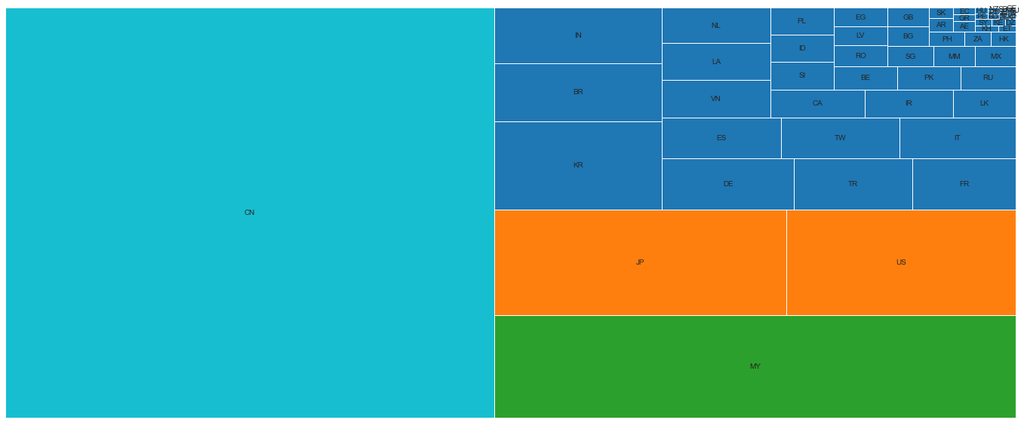

```python
plt.figure(figsize=(24,10))
cmap = matplotlib.cm.tab10
mini=min(rubber.loc[rubber.month == 12].acc_value_baht)
maxi=max(rubber.loc[rubber.month == 12].acc_value_baht)
norm = matplotlib.colors.Normalize(vmin=mini, vmax=maxi)
colors = [cmap(norm(value)) for value in rubber.loc[rubber.month == 12].acc_value_baht]

squarify.plot(sizes=rubber.loc[rubber.month == 12].acc_value_baht, label=rubber.loc[rubber.month == 12].country_code, alpha=1,color=colors )
plt.axis('off')
plt.show()
```

this tree map shown that China has import large amount because they need to make car tiles and shoes.

จีนเป็นหนึ่งในประเทศที่มีความพยายามในด้านการพัฒนาอุตสาหกรรมรถยนต์แต่ไม่สามารถผลิตยางรถบนต์ออกมาได้เองในปริมาณที่มากดังนั้นจึงได้ทำการนำเข้ายางพาราจากประเทศไทยซึ่งอีกหนึ่งประเทศคือมาเลเซียที่มีฐานการประกอบรถยนต์ส่งออกในภูมิภาคเอเชียด้วยเช่นกัน ref:http://www.taifhasai.co.th/17-news/60-news2.html ,https://www.ditp.go.th/contents_attach/92605/92605.pdf

จากtreemapมุมขวาบนเราจะเห็นตัวอักษรหรือตัวย่อประเทศทับกันอยู่เนื่องจากว่าเป็นประเทศที่มีการส่งออกที่น้อยมากและอยู่นกลุ่มเดียวกันทำให้อยู่กันเป็นกลุ่มในส่วนนั้น

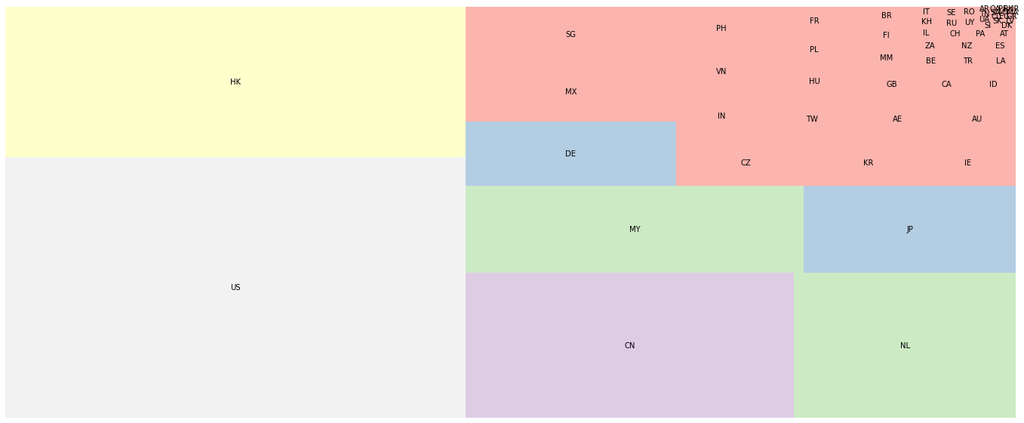

```python
plt.figure(figsize=(24,10))
cmap = matplotlib.cm.Pastel1
mini=min(com.loc[com.month == 12].acc_value_baht)
maxi=max(com.loc[com.month == 12].acc_value_baht)
norm = matplotlib.colors.Normalize(vmin=mini, vmax=maxi)
colors = [cmap(norm(value)) for value in com.loc[com.month == 12].acc_value_baht]

squarify.plot(sizes=com.loc[com.month == 12].acc_value_baht, label=com.loc[com.month == 12].country_code, alpha=1,color=colors )
plt.axis('off')
plt.show()
```

อุปกรณ์หรือชิ้นส่วนประกอบคอมพิวเตอร์เป็นอีกหนึ่งสิ่งที่ประเทศเราส่งออกในปริมมาณที่มากโดยเฉพาะประเทศที่พัฒนาในด้าคอมพิวเตอร์อย่างประเทศอเมริกาที่เป็นสถานที่รวมบริษัทเทคโนโลยีจำพวกกลุ่ม FANG ซึ่งในการพัฒนาอุปกรณ์ IOT หรือ เครื่องเซิฟเวอร์จำเป็นต้องนำเข้าคอมพิวเตอร์ อุปกรณ์ ชิ้นส่วนเพื่อนำไปพัฒนาอุตสาหกรรมด้านนี้ของประเทศ

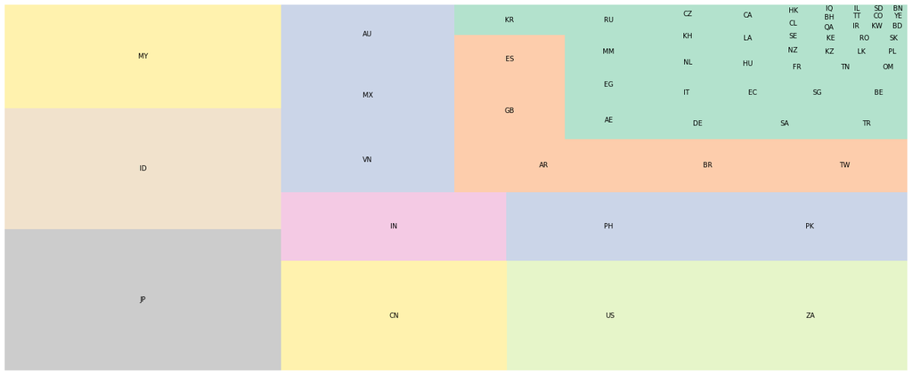

```python
plt.figure(figsize=(24,10))
cmap = matplotlib.cm.Pastel2
mini=min(car.loc[car.month == 12].acc_value_baht)
maxi=max(car.loc[car.month == 12].acc_value_baht)
norm = matplotlib.colors.Normalize(vmin=mini, vmax=maxi)
colors = [cmap(norm(value)) for value in car.loc[car.month == 12].acc_value_baht]

squarify.plot(sizes=car.loc[car.month == 12].acc_value_baht, label=car.loc[car.month == 12].country_code, alpha=1,color=colors )
plt.axis('off')
plt.show()
```

อุปกรณ์รถยนต์เป็นอีกหนึ่งสิ่งที่ส่งออกในมูลค่าที่มากในหลายประเทศโดยเฉพาะในเอเชียที่เป็นแหล่งผลิตรถยนต์ให้กับหลายยี่ห้อเนื่องจากค่าแรงที่ถูกกว่า ซึ่งประเทศเหล่านั้นจะต้องใช้อุปกรณ์จำนวนมากดังนั้นจึงเป็นตลาดที่ค่อนข้างน่าสนใจ

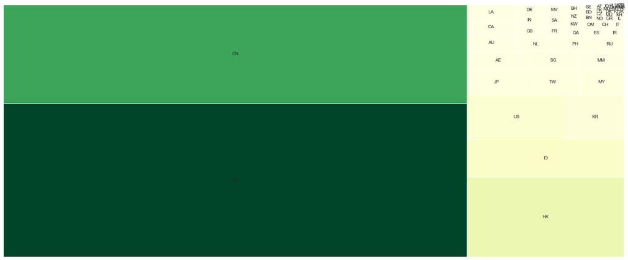

```python
plt.figure(figsize=(24,10))
cmap = matplotlib.cm.YlGn
mini=min(fruits.loc[fruits.month == 12].acc_value_baht)
maxi=max(fruits.loc[fruits.month == 12].acc_value_baht)
norm = matplotlib.colors.Normalize(vmin=mini, vmax=maxi)
colors = [cmap(norm(value)) for value in fruits.loc[fruits.month == 12].acc_value_baht]

squarify.plot(sizes=fruits.loc[fruits.month == 12].acc_value_baht, label=fruits.loc[fruits.month == 12].country_code, alpha=1,color=colors )
plt.axis('off')
plt.show()
```

ไทยเราส่งออกผลไม้หลักๆ ได้มีการส่งออกกไปที่ประเทศเวียดนามและประเทศจีน ในบางส่วนจะเหมือนกับข้าวของประเทศเบนินคือการส่งส่งไปเวียดนามก่อนแล้วส่งผ่านชายแดนสู่ประเทศจีน

ข้อมูลเพิ่มเติม:https://www.ditp.go.th/contents_attach/172838/172838.pdf

## ASEAN

```python
options = ['VN', 'MY','ID','SG','PH',"KH",'MM','LA','BN']
asean_df = clean_data[clean_data['country_code'].isin(options)] #สร้างตัวเลือกมาแล้วดูข้อมูลที่อยู่ในตัวเลือกoptions
asean_df[(asean_df["month"] == 12)].sort_values(by='acc_value_baht_export', ascending=False)
```

|  | year | month | country_code | country_name_th | value_baht_export | acc_value_baht_export | value_baht_import | acc_value_baht_import | value_baht_balance | acc_value_baht_balance |
| --- | --- | --- | --- | --- | --- | --- | --- | --- | --- | --- |
| 664 | 2017 | 12 | VN | เวียดนาม | 3.768113e+10 | 3.912109e+11 | 1.453568e+10 | 1.696389e+11 | 2.314545e+10 | 2.215719e+11 |
| 663 | 2017 | 12 | MY | มาเลเซีย | 2.837554e+10 | 3.498487e+11 | 2.895716e+10 | 3.970258e+11 | -5.816255e+08 | -4.717714e+10 |
| 666 | 2017 | 12 | ID | อินโดนีเซีย | 2.054867e+10 | 2.994945e+11 | 1.974330e+10 | 2.503596e+11 | 8.053619e+08 | 4.913488e+10 |
| 665 | 2017 | 12 | SG | สิงคโปร์ | 2.015750e+10 | 2.811208e+11 | 1.894644e+10 | 2.706859e+11 | 1.211062e+09 | 1.043486e+10 |
| 675 | 2017 | 12 | PH | ฟิลิปปินส์ | 1.636897e+10 | 2.349634e+11 | 9.080009e+09 | 1.107186e+11 | 7.288964e+09 | 1.242447e+11 |
| 679 | 2017 | 12 | KH | กัมพูชา | 2.023083e+10 | 1.790828e+11 | 2.030609e+09 | 3.073948e+10 | 1.820023e+10 | 1.483433e+11 |
| 678 | 2017 | 12 | MM | เมียนม่า | 1.189506e+10 | 1.461423e+11 | 7.929953e+09 | 8.434896e+10 | 3.965106e+09 | 6.179334e+10 |
| 680 | 2017 | 12 | LA | ลาว | 1.273136e+10 | 1.336945e+11 | 6.922100e+09 | 7.586887e+10 | 5.809256e+09 | 5.782566e+10 |
| 709 | 2017 | 12 | BN | บรูไน | 2.146041e+08 | 2.755455e+09 | 2.599863e+09 | 2.003105e+10 | -2.385259e+09 | -1.727559e+10 |

### boxplot by export amount of ASEAN country

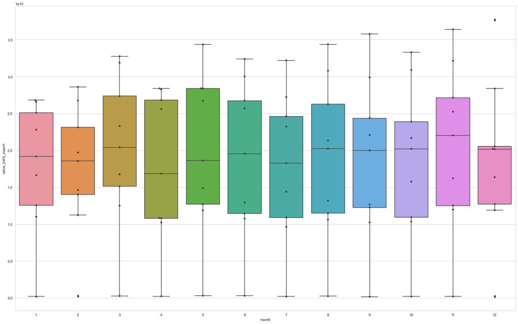

```python
plt.figure(figsize=(24,15))
ax = sns.boxplot(x="month", y="value_baht_export", data=asean_df)
ax = sns.swarmplot(x="month", y="value_baht_export", data=asean_df, color=".25")
```

As you see they are one of ASEAN country that less import goods from Thailand

เราจะเห็นได้ว่าในแต่ละเดือนจะไม่มี outlier เยอะเหมือนรวม60ประเทศแต่จะเห็นได้ว่า ข้อมูลจะอยู่กันเป็นกลุ่ม จะมีบางส่วนที่จะเป็น outlier ทั้งแบบต่ำและแบบสูง

### เปรียบเทียบขนาดการส่งออกของประเทศในอาเซียนด้วย treemap

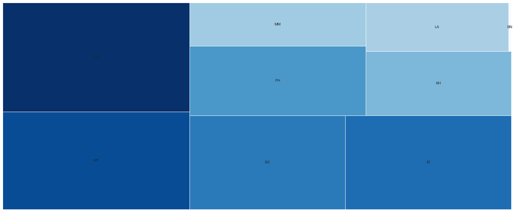

```python
plt.figure(figsize=(24,10))
"""Map color by values """
cmap = matplotlib.cm.Blues
mini=min(asean_df.loc[asean_df.month == 12].acc_value_baht_export)
maxi=max(asean_df.loc[asean_df.month == 12].acc_value_baht_export)
norm = matplotlib.colors.Normalize(vmin=mini, vmax=maxi)
colors = [cmap(norm(value)) for value in asean_df.loc[asean_df.month == 12].acc_value_baht_export]

squarify.plot(sizes=asean_df.loc[asean_df.month == 12].acc_value_baht_export, label=asean_df.loc[asean_df.month == 12].country_code, alpha=1,color=colors )
plt.axis('off')
plt.show()
```

### Why Brunei is the least export country

Brunei is making money by selling gasoline, and most of the country that have connect/trading with brunei are Islamic country

เนื่องจากเป็นประเทศที่มีสถานการณ์ในการค้าส่วนมากเป็นการส่งออกน้ำมันอย่างมหาศาลทำให้แทบไม่มีความจำเป็นในการนำเข้าสินค้าอุตสาหกรรมจากไทยเป็นจำนวนที่มาก รวมถึงการที่เป็นประเทศที่มีศาสนาประจำชาติเป็นอิสลามทำให้เรื่องของวัฒนธรรมมีความแตกต่างทำให้มีการค้าขายกับประเทศฝั่งตะวันออกมากกว่า

ข้อมูลเพิ่มเติม:https://www.ditp.go.th/contents_attach/221328/221328.pdf

```python
"""ทำการเลือกข้อมูลที่เกี่ยวข้องกับอาเซียน"""
riceas_df = rice[rice['country_code'].isin(options)]
rubber_df = rubber[rubber['country_code'].isin(options)]
com_df = com[com['country_code'].isin(options)]
car_df = car[car['country_code'].isin(options)]
fruits_df = fruits[fruits['country_code'].isin(options)]
industry_df = industry[industry['country_code'].isin(options)]
```

### แสดงมูลค่าการส่งออกในอาเซียนโดยไม่รวมสินค้าอุตสาหกรรม

```
[Text(0.5, 0, 'hundred billion(baht)')]
```

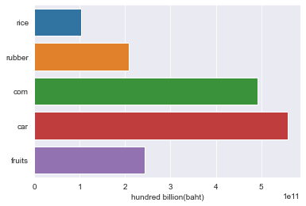

```python
#ไม่รวม industry เนื่องจากว่า industry มีขนาดที่ใหญ่เกินไป
sns.set_style(style="darkgrid") #กำหนดสไตล์ของพื้นหลังกราฟ
x = [riceas_df['acc_value_baht'].sum(),rubber_df['acc_value_baht'].sum(),com_df['acc_value_baht'].sum(),car_df['acc_value_baht'].sum(),\
    fruits_df['acc_value_baht'].sum()]
y = ['rice','rubber','com','car','fruits']
ax = sns.barplot(x, y)
ax.set(xlabel="hundred billion(baht)")
```

This graph show export data in ASEAN country with out Industry Goods(except car and computer goods) จากกราฟข้างบนเราจะเห็นว่าเราจะไม่นำข้อมูลชองสินค้าอุตสาหกรรมมาแสดงเพราะว่าจะมีมูลค่าเยอะเกินไปจนเปรียบเทียบได้ยากดังนั้นเราจะมากดูกันแค่ในส่วนของปริมารสินค้าส่งออกที่น้อยกว่า

### Market Sharing/Portion by a kind of export goods in Vietnam

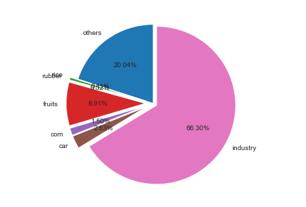

```python
vn_pie = sum_datas.loc[sum_datas.country_code =="VN"].acc_value_baht_export.sum()
rice_savalue = rice.loc[(rice.month == 12)&(rice.country_code == 'VN')].acc_value_baht.sum()
rubber_savalue = rubber.loc[(rubber.month == 12)&(rubber.country_code == 'VN')].acc_value_baht.sum()
fruits_savalue = fruits.loc[(fruits.month == 12)&(fruits.country_code == 'VN')].acc_value_baht.sum()
com_savalue = com.loc[(com.month == 12)&(com.country_code == 'VN')].acc_value_baht.sum()
car_savalue = car.loc[(car.month == 12)&(car.country_code == 'VN')].acc_value_baht.sum()
industry_savalue = industry.loc[(industry.month == 12)&(industry.country_code == 'VN')].acc_value_baht.sum()
industry_savalue = float(industry_savalue) - float(com_savalue) - float(car_savalue)#ต้องลบ com car ออกจาก industry
others = float(vn_pie)-float(rice_savalue)-float(fruits_savalue)-float(rubber_savalue)-float(com_savalue)\
-float(car_savalue)-float(industry_savalue)
fig = plt.figure()
ax = fig.add_axes([0,0,1,1])
ax.axis('equal')
explode = (0, 0.1, 0.1, 0.1,0.1,0.1,0.05)

"""

"""
country = ['others',  'rice', 'rubber','fruits','com','car','industry']
val = [others,rice_savalue,rubber_savalue,fruits_savalue,com_savalue,car_savalue,industry_savalue]
ax.pie(val, labels = country ,autopct='%1.2f%%', explode=explode, shadow=False, startangle=90)# ทำมุม90 ในส่วนของอันแรก
plt.show()
```

จากข้อมูลนี้เราจะเห็นได้ว่าเวียดนามเป็นประเทศที่มีการนำเข้าผลไม้ซึ่งน่าจะเยอะมาก

### Market Sharing/portion by a kind of export goods in Malaysia

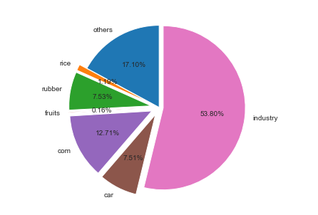

```python
my_pie = sum_datas.loc[sum_datas.country_code =="MY"].acc_value_baht_export.sum()
rice_savalue = rice.loc[(rice.month == 12)&(rice.country_code == 'MY')].acc_value_baht.sum()
rubber_savalue = rubber.loc[(rubber.month == 12)&(rubber.country_code == 'MY')].acc_value_baht.sum()
fruits_savalue = fruits.loc[(fruits.month == 12)&(fruits.country_code == 'MY')].acc_value_baht.sum()
com_savalue = com.loc[(com.month == 12)&(com.country_code == 'MY')].acc_value_baht.sum()
car_savalue = car.loc[(car.month == 12)&(car.country_code == 'MY')].acc_value_baht.sum()
industry_savalue = industry.loc[(industry.month == 12)&(industry.country_code == 'MY')].acc_value_baht.sum()
industry_savalue = float(industry_savalue) - float(com_savalue) - float(car_savalue)
others = float(my_pie)-float(rice_savalue)-float(fruits_savalue)-float(rubber_savalue)-float(com_savalue)\
-float(car_savalue)-float(industry_savalue)
fig = plt.figure()
ax = fig.add_axes([0,0,1,1])
ax.axis('equal')
explode = (0, 0.1, 0.1, 0.1,0.1,0.1,0.05)


country = ['others',  'rice', 'rubber','fruits','com','car','industry']
val = [others,rice_savalue,rubber_savalue,fruits_savalue,com_savalue,car_savalue,industry_savalue]
ax.pie(val, labels = country ,autopct='%1.2f%%', explode=explode, shadow=False, startangle=90)# ทำมุม90 ในส่วนของอันแรก
plt.show()
```

ประเทศมาเลเซียนเราจะเห็นได้ว่ามีการนำเข้ายางมาเยอะ และอุปกรณ์รถยนต์เพราะว่าเป็นประเทศที่ผลิตรถยนต์ให้กับหลายยี่ห้อ

### Market Sharing/portion by a kind of export goods in Indonesia

ประเทศนี้จะไม่ค่อยมีอะไรมากกับประเทศไทย

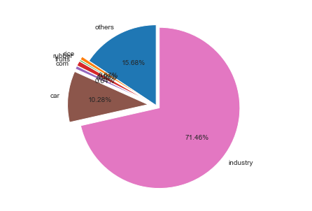

```python
id_pie = sum_datas.loc[sum_datas.country_code =="ID"].acc_value_baht_export.sum()
rice_savalue = rice.loc[(rice.month == 12)&(rice.country_code == 'ID')].acc_value_baht.sum()
rubber_savalue = rubber.loc[(rubber.month == 12)&(rubber.country_code == 'ID')].acc_value_baht.sum()
fruits_savalue = fruits.loc[(fruits.month == 12)&(fruits.country_code == 'ID')].acc_value_baht.sum()
com_savalue = com.loc[(com.month == 12)&(com.country_code == 'ID')].acc_value_baht.sum()
car_savalue = car.loc[(car.month == 12)&(car.country_code == 'ID')].acc_value_baht.sum()
industry_savalue = industry.loc[(industry.month == 12)&(industry.country_code == 'ID')].acc_value_baht.sum()
industry_savalue = float(industry_savalue) - float(com_savalue) - float(car_savalue)
others = float(id_pie)-float(rice_savalue)-float(fruits_savalue)-float(rubber_savalue)-float(com_savalue)\
-float(car_savalue)-float(industry_savalue)
fig = plt.figure()
ax = fig.add_axes([0,0,1,1])
ax.axis('equal')
explode = (0, 0.1, 0.1, 0.1,0.1,0.1,0.05)


country = ['others',  'rice', 'rubber','fruits','com','car','industry']
val = [others,rice_savalue,rubber_savalue,fruits_savalue,com_savalue,car_savalue,industry_savalue]
ax.pie(val, labels = country ,autopct='%1.2f%%', explode=explode, shadow=False, startangle=90)# ทำมุม90 ในส่วนของอันแรก
plt.show()
```

### Market Sharing/portion by a kind of export goods in Singapore

ส่วนมากประเทศนี้จะไม่ค่อยนำเข้าอะไรมากนอกจากที่ใช้ในอุตสาหกรรม

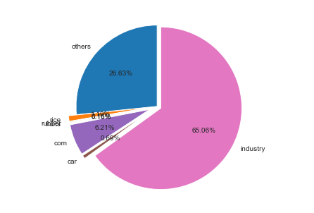

```python
sg_pie = sum_datas.loc[sum_datas.country_code =="SG"].acc_value_baht_export.sum()
rice_savalue = rice.loc[(rice.month == 12)&(rice.country_code == 'SG')].acc_value_baht.sum()
rubber_savalue = rubber.loc[(rubber.month == 12)&(rubber.country_code == 'SG')].acc_value_baht.sum()
fruits_savalue = fruits.loc[(fruits.month == 12)&(fruits.country_code == 'SG')].acc_value_baht.sum()
com_savalue = com.loc[(com.month == 12)&(com.country_code == 'SG')].acc_value_baht.sum()
car_savalue = car.loc[(car.month == 12)&(car.country_code == 'SG')].acc_value_baht.sum()
industry_savalue = industry.loc[(industry.month == 12)&(industry.country_code == 'SG')].acc_value_baht.sum()
industry_savalue = float(industry_savalue) - float(com_savalue) - float(car_savalue)
others = float(sg_pie)-float(rice_savalue)-float(fruits_savalue)-float(rubber_savalue)-float(com_savalue)\
-float(car_savalue)-float(industry_savalue)
fig = plt.figure()
ax = fig.add_axes([0,0,1,1])
ax.axis('equal')
explode = (0, 0.1, 0.1, 0.1,0.1,0.1,0.05)


country = ['others',  'rice', 'rubber','fruits','com','car','industry']
val = [others,rice_savalue,rubber_savalue,fruits_savalue,com_savalue,car_savalue,industry_savalue]
ax.pie(val, labels = country ,autopct='%1.2f%%', explode=explode, shadow=False, startangle=90)# ทำมุม90 ในส่วนของอันแรก
plt.show()
```

# Summary

Thailand has 2 factor to growing up country 1.Selling (Export) 2.Tourism.

From data Thailand export a lot of thing most of that things is Inddustry goods.

The Great country need a lot of resource/component to make a huge develop technology and Thailand has that resource.

From Data we can see china have a large amount of import to their country but Thailand import their things too, Accroding from

Data Trade Balance is of China is Negative In Huge Number so Thailand has a lot of loss by China.